# Day 5: Data visualization in R

E. Anne Chambers

The files you’ll need for this exercise can be found [here](https://utexas.box.com/s/82sgrvghrc4m2262heav7ak50310cmhd). Download the `Day5_datavis_worksheet_files` folder, and move it to whichever directory this markdown file is currently in so R knows where to look. Load the dependencies below.

```r
# install.packages("ggplot2")
# install.packages("ape")
# install.packages("ggtree")
# install.packages("tidyverse")
library(ggplot2)
library(ape)
library(ggtree)
library(tidyverse)
library(here) # this will set up your working directory properly
```

## Exercise 1a: ggplot basics

Let’s build some plots using data you’ve acquired. Both files included in the Day 5 folder are tab-separated files, so we can use the function `read_tsv` to import them. They have column names so we need to set `col_names` to true.

The first file is called `rana_stats.txt` and is simply the last part of the final Rana ddRAD stats file from iPyrad. Let’s take a look.

```r
# Import data file
stats <- read_tsv(here("data", "Day5_datavis_worksheet_files/rana_stats.txt"), col_names = TRUE)
# View the stats data frame; you should recognize this from the iPyrad class!
stats
```

```
## # A tibble: 12 × 10
##    sample_ID state reads_raw reads_passed_filter clusters_total clusters_hidepth
##    <chr>     <dbl>     <dbl>               <dbl>          <dbl>            <dbl>
##  1 Rber_T11…     7   1325769             1325165         322924            52046
##  2 Rber_T11…     7    990429              990042         274337            39378
##  3 Rber_T11…     7    526937              526750         155871            20028
##  4 Rbla_D28…     7   1013594             1013181         211491            42789
##  5 Rbla_D28…     7    783243              782909         187525            33110
##  6 Rchi_T20…     7    748006              747668         208201            19182
##  7 Rchi_T20…     7    893997              893551         231457            25511
##  8 Rchi_T20…     7    718310              717980         202394            18530
##  9 Rneo_T480     7   1080926             1080515         283418            43132
## 10 Rneo_T527     7   1079884             1079458         246068            45492
## 11 Rsph_T25…     7   1095559             1095093         320685            43811
## 12 Rsph_T26…     7   1102849             1102357         329863            43283
## # ℹ 4 more variables: hetero_est <dbl>, error_est <dbl>, reads_consens <dbl>,
## #   loci_in_assembly <dbl>
```

1. Make a plot with loci in assembly on the y-axis vs. sample on the x-axis, but make each sample have a **point** rather than a bar.

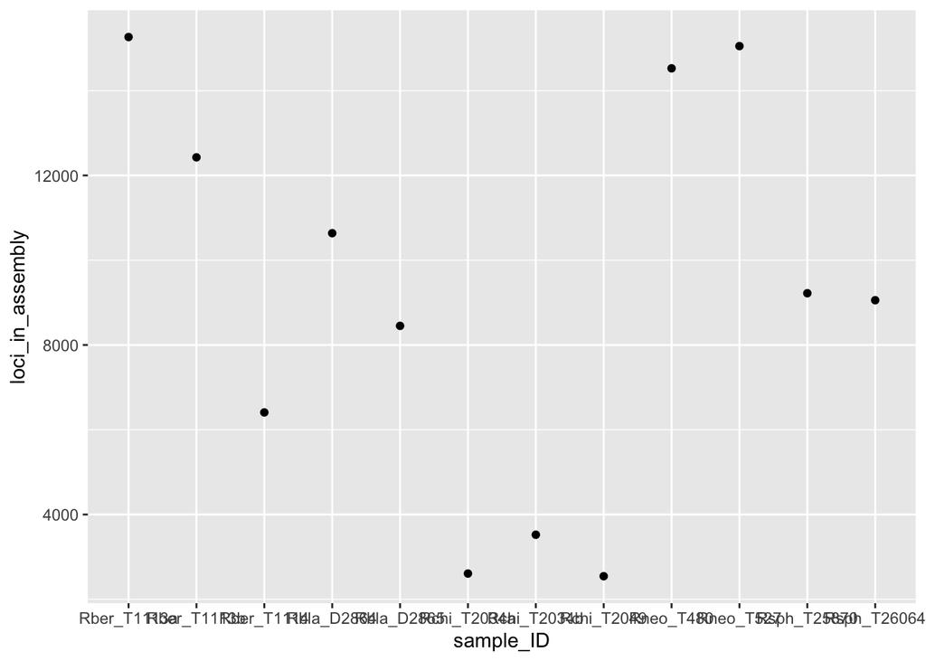

```r
ggplot(stats, aes(x = sample_ID, y = loci_in_assembly)) +
  geom_point()
```

2. Color each data point by sample ID and remove the x axis labels (by adding the following) because they’re now redundant. `theme(axis.title.x=element_blank(), axis.text.x=element_blank(), axis.ticks.x=element_blank())`

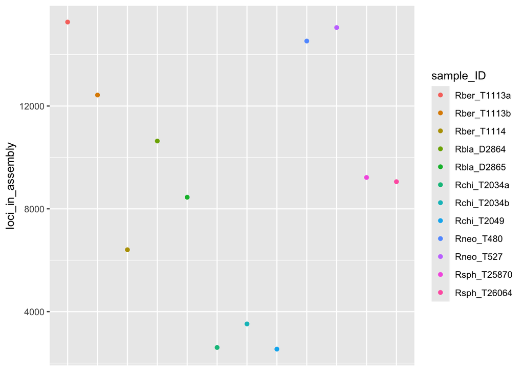

```r
ggplot(stats, aes(x = sample_ID, y = loci_in_assembly, color = sample_ID)) +
  geom_point() +
  theme(axis.title.x = element_blank(),
        axis.text.x = element_blank(),
        axis.ticks.x = element_blank())
```

## Exercise 1b: ggplot basics

Let’s take a look at amounts of missing data now. There is another file in the data directory (`rana_missing_data.txt`) that takes these same samples we’ve been working with and has the number of sites and percentage of missing data.

1. Import the `rana_missing_data.txt` file as you did the stats file above and call it `missing`. Take a look at the file contents.

```r
missing <- read_tsv(here("data", "rana_missing_data.txt"))
missing
```

```
## # A tibble: 12 × 3
##    sample_ID    number_sites percent_missing
##    <chr>               <dbl>           <dbl>
##  1 Rber_T1113a        578589            25.7
##  2 Rber_T1113b        890122            39.5
##  3 Rber_T1114        1551646            68.8
##  4 Rbla_D2864        1088206            48.2
##  5 Rbla_D2865        1327989            58.9
##  6 Rchi_T2034a       1970040            87.3
##  7 Rchi_T2034b       1869626            82.9
##  8 Rchi_T2049        1976841            87.6
##  9 Rneo_T480          660654            29.3
## 10 Rneo_T527          603239            26.7
## 11 Rsph_T25870       1243467            55.1
## 12 Rsph_T26064       1261572            55.9
```

2. Make a **bar plot** with percentage of missing data on the y-axis vs. sample ID on the x-axis.

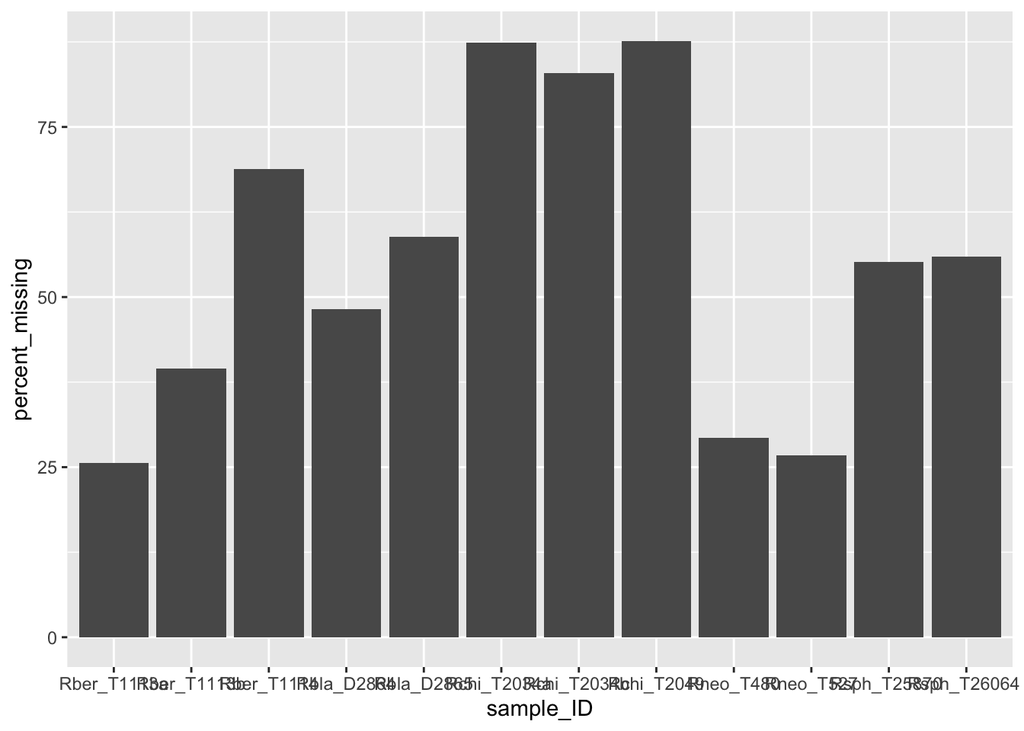

```r
ggplot(missing, aes(x = sample_ID, y = percent_missing)) +
  geom_col()
```

3. Outline AND fill the bars (two separate functions, see if you can figure this out on your own) according to sample ID and remove the x axis labels, title, and ticks as you did in 1a.

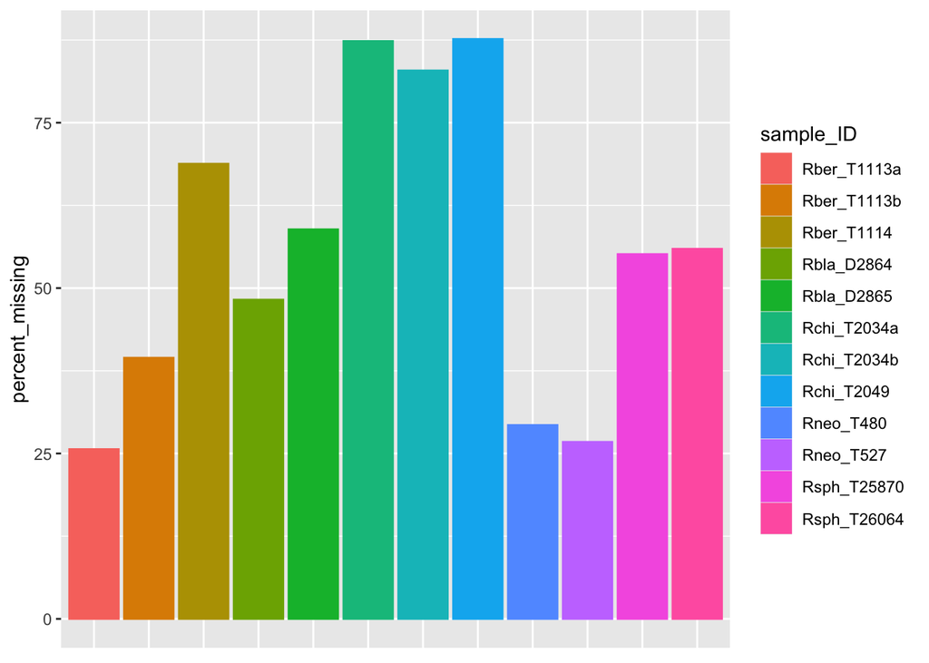

```r
ggplot(missing, aes(x = sample_ID, y = percent_missing, color = sample_ID, fill = sample_ID)) +
  geom_col() +
  theme(axis.title.x = element_blank(),
        axis.text.x = element_blank(),
        axis.ticks.x = element_blank())
```

## Exercise 2: ggtree basics

For `ggtree()`, we’re going to use the Nexus file that you created from the Day 4 RAxML worksheet. If you haven’t had a chance to do this yet, download the relevant tree files from the data directory on GitHub and go to the part of the 4t_Phylo_tutorial.docx file called “Make a Nexus tree file”.

To recap, this Nexus file should contain the Rana ddRAD tree *with support values and branch lengths*. Move (or copy) that file to the current working directory. The file should be called `ranaddrad_tree.nexus`. You can also find it in the data directory on GitHub.

As we discussed in lecture, you need to import the Nexus file as a `phylo object`, using the `ape()` package. To do this:

```r
# Import the tree
tree <- read.nexus(here("data", "ranaddrad_tree.nexus"))
# Take a look at the tree to understand the format of a phylo object
tree
```

```
##
## Phylogenetic tree with 12 tips and 10 internal nodes.
##
## Tip labels:
##   Rneo_T527, Rber_T1113a, Rber_T1113b, Rber_T1114, Rsph_T26064, Rsph_T25870, ...
## Node labels:
##   , 100, 100, 100, 100, 86, ...
##
## Rooted; includes branch lengths.
```

```r
# To access the different objects within a phylo object, we can use the dollar sign. What appears when you enter the following?:
tree$Nnode
```

```
## [1] 10
```

1. How do you take a look at the taxon names of this tree?

```r
tree$tip.label
```

```
##  [1] "Rneo_T527"   "Rber_T1113a" "Rber_T1113b" "Rber_T1114"  "Rsph_T26064"
##  [6] "Rsph_T25870" "Rbla_D2865"  "Rbla_D2864"  "Rchi_T2034b" "Rchi_T2034a"
## [11] "Rchi_T2049"  "Rneo_T480"
```

Run the following code, which builds a tree in `ggtree` with the absolute minimum amount of labeling.

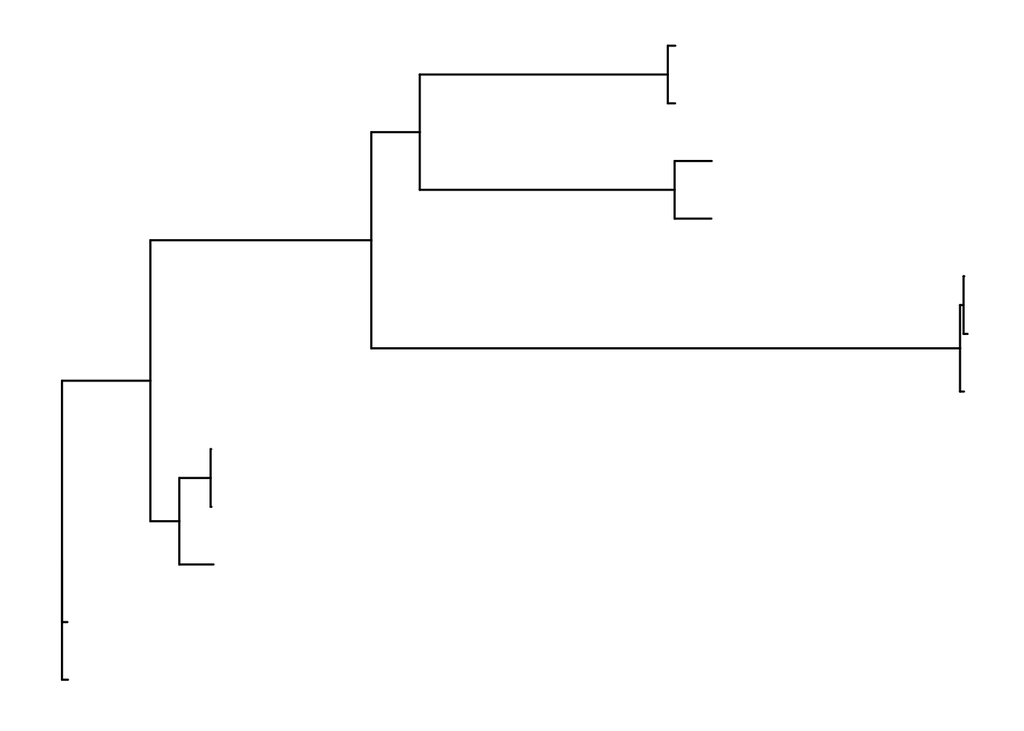

```r
ggtree(tree)
```

2. Add tip labels to this tree using the `geom_tiplab()` function within `ggtree`.

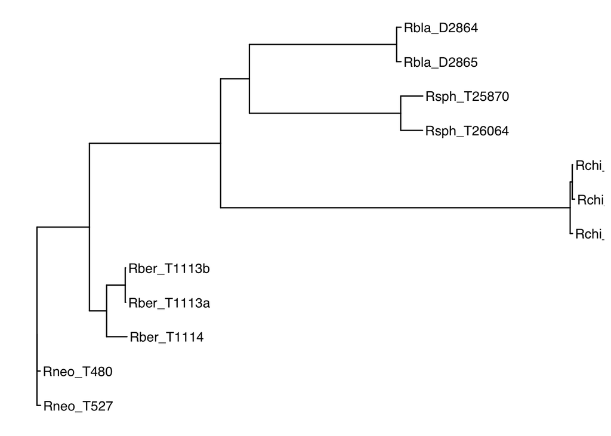

```r
ggtree(tree) +
  geom_tiplab()
```

3. You may have noticed that the rooting of this tree is incorrect. We need to reroot the tree before proceeding, but first we need to figure out which node to reroot the tree at (the one that is the common ancestor of all *R. chiricahuensis* individuals) using its *node number*. Working off your tree from 2. and using the `geom_text()` function within `ggtree`, plot node numbers on the tree you built. You will have to specify the aes.

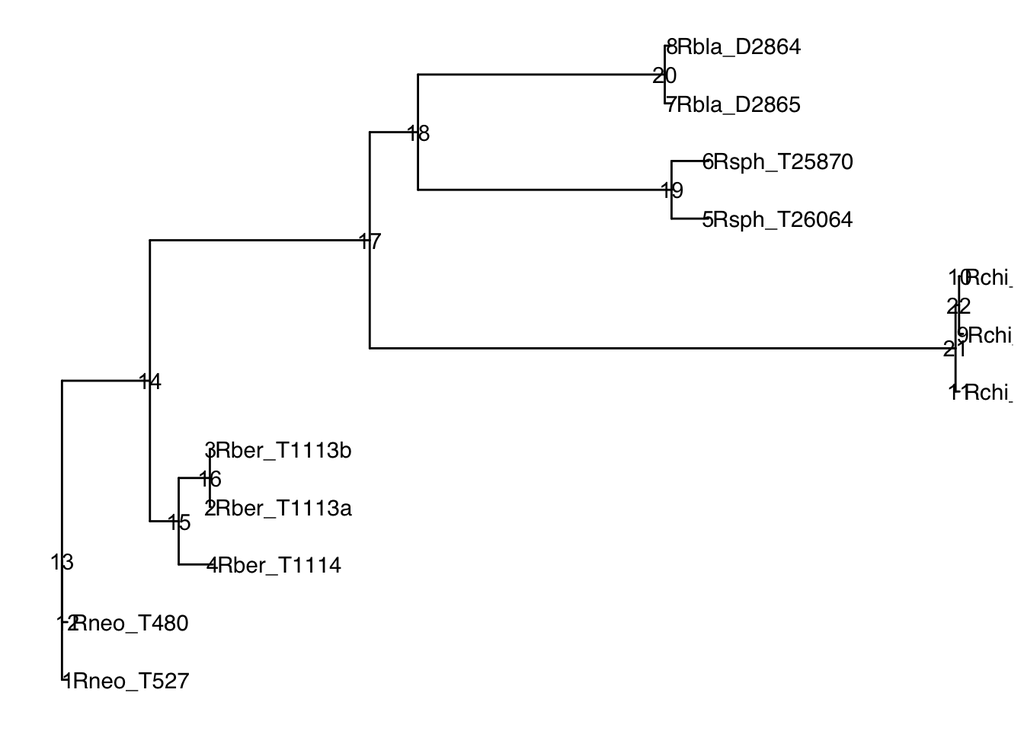

```r
ggtree(tree) +
  geom_tiplab() +
  geom_text(aes(label = node))
```

4. Now, reroot the tree at the correct node. We can do this using the `root()` function within `ape` with the syntax `rooted_tree <- root(tree, node=X, edgelabel=TRUE)`. `edgelabel` retains the branch lengths.

```r
rooted_tree <- root(tree,
                    node = 21,
                    edgelabel = TRUE)
```

5. Rerun the code from 2. but for the new tree. Is the new tree rooted correctly?

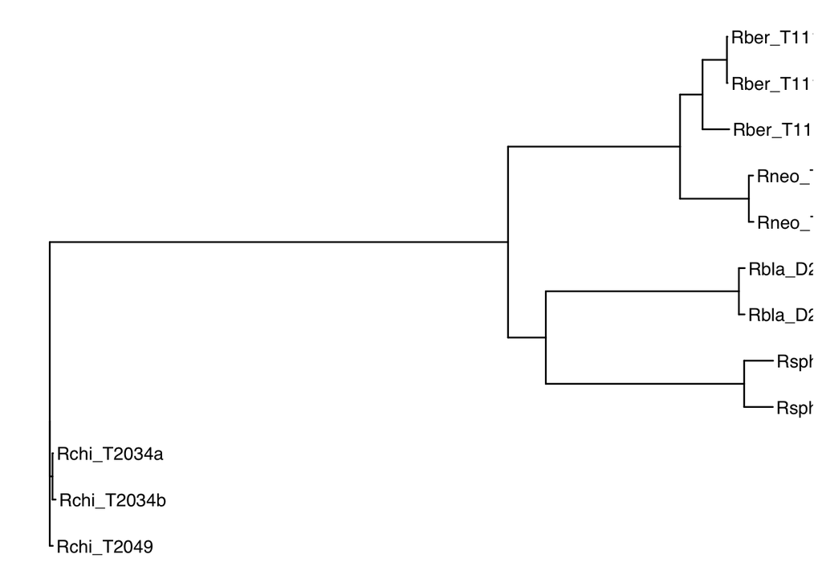

```r
ggtree(rooted_tree) +
  geom_tiplab() # yes, tree is now rooted correctly
```

6. Working off the tree above, also add on node labels that are the bootstrap support values using the `geom_text` function within `ggtree`. The labeling should be `label`.

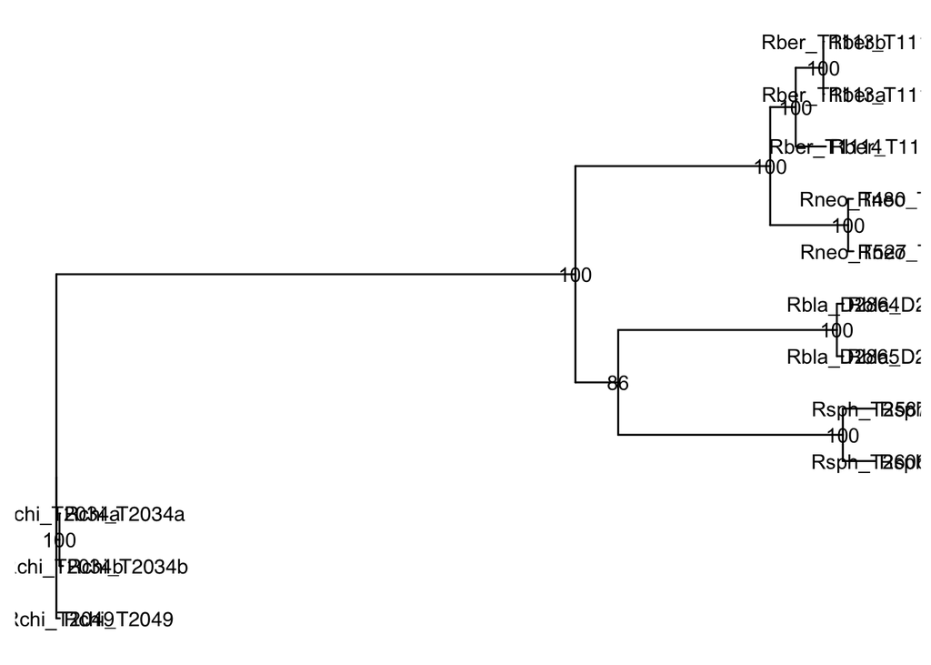

```r
ggtree(rooted_tree) +
  geom_tiplab() +
  geom_text(aes(label = label))
```

7. There’s a lot going on in the above tree and it’s hard to make out the BS values. Rebuild the tree instead with points at the nodes of the tree (using `geom_nodepoint`) that are colored according to bootstrap support value. Specify coloring by `label` (within the aesthetic) and make the size of the points be 2.

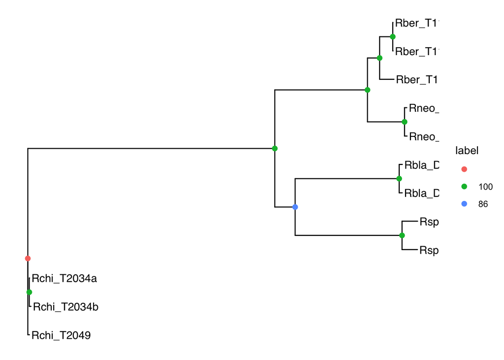

```r
ggtree(rooted_tree) +
  geom_tiplab() +
  geom_nodepoint(aes(label = label, color = label), size = 2)
```

8. Specify the colors for the bootstrap node points by using the `scale_color_manual(values=c("color1", "color2", "color3"))` function. There are three different values for the bootstrap support so you’ll need to provide three different color names. Examples of R color names can be found [here](http://www.stat.columbia.edu/~tzheng/files/Rcolor.pdf).

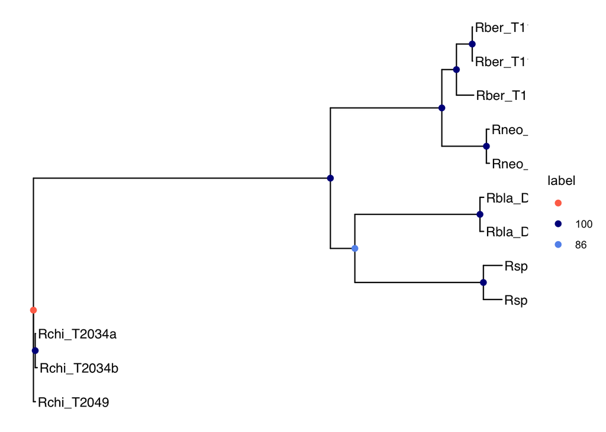

```r
ggtree(rooted_tree) +
  geom_tiplab() +
  geom_nodepoint(aes(label = label, color = label), size = 2) +
  scale_color_manual(values = c("coral1", "darkblue", "cornflowerblue"))
```

9. The legend with the bootstrap colors is obscuring some of your tip labels. We can move the legend around using the exact same function as in normal `ggplot()`, which is the function `theme()`. Add on `theme(legend.position="bottom")`

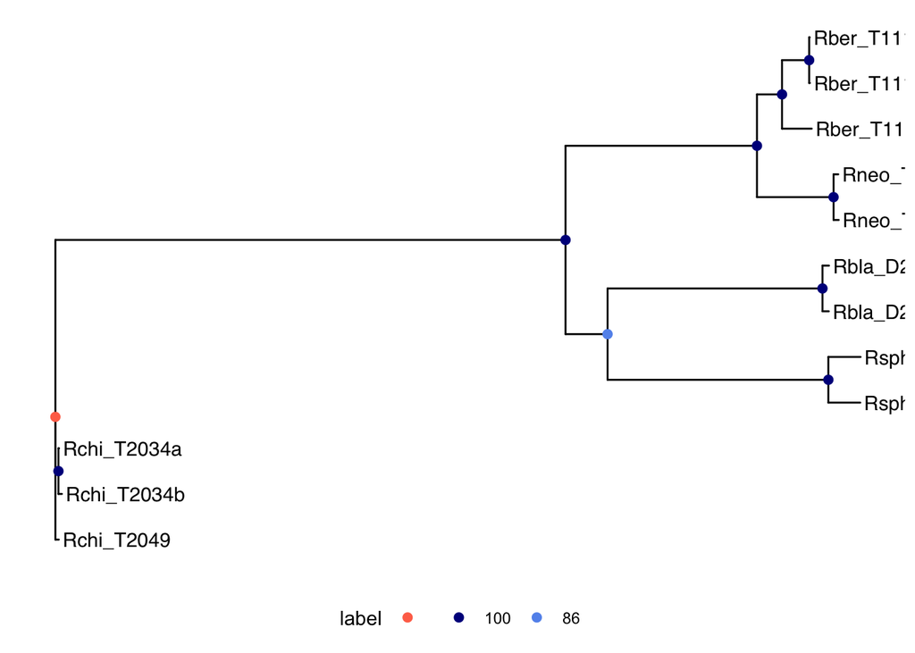

```r
ggtree(rooted_tree) +
  geom_tiplab() +
  geom_nodepoint(aes(label = label, color = label), size = 2) +
  scale_color_manual(values = c("coral1", "darkblue", "cornflowerblue")) +
  theme(legend.position = "bottom")
```

10. Finally, add a scale bar to the plot using the `geom_treescale` function within `ggtree`. Save this visualization as `plot_tree`.

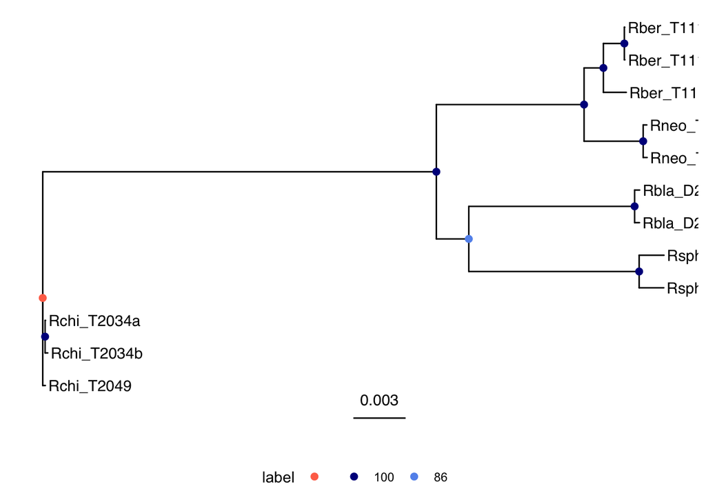

```r
ggtree(rooted_tree) +
  geom_tiplab() +
  geom_nodepoint(aes(label = label, color = label), size = 2) +
  scale_color_manual(values = c("coral1", "darkblue", "cornflowerblue")) +
  theme(legend.position = "bottom") +
  geom_treescale()
```

11. You can export your tree in a few ways, but we’ll use the `ggsave` function within `ggplot2`. This will save the PDF to your current working directory.

```
ggsave("ranaddrad_tree.pdf", plot_tree)
```

## Advanced exercise

`ggtree()` uses a special symbol `%<+%` to add on other data to the tree. The syntax for this is `plot_tree %<+% newdata + geomstoadd`. However, we actually need to remove the bootstrap support node colors first.

1. Using your properly rooted phylo object (`rooted_tree`), build a new tree plot without any information at the nodes (labels or node points). Name this `tree_nonodes`.

```r
tree_nonodes <-
  ggtree(rooted_tree) +
  geom_tiplab() +
  theme(legend.position = "bottom") +
  geom_treescale()
```

2. Using the `missing` dataframe, add this on to your existing tree plot (`tree_nonodes`) and add tip points using `geom_tippoint()`. Fill the points by percentage missing data and give them a size of 2.

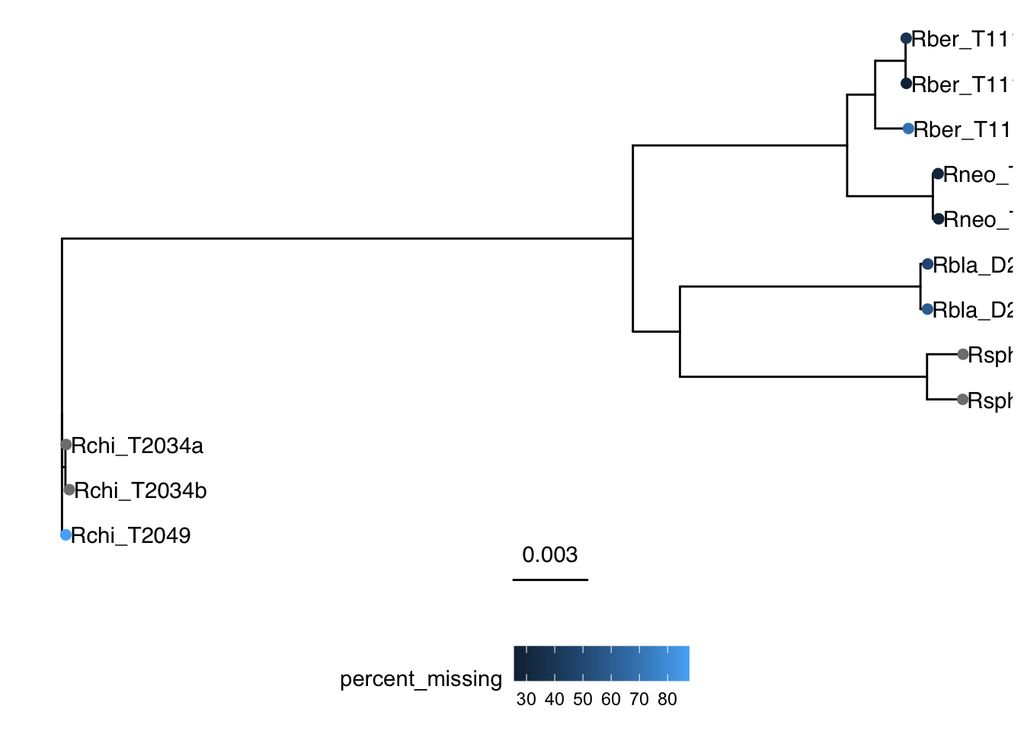

```r
tree_nonodes %<+%
  missing +
  geom_tippoint(aes(color = percent_missing), size = 2)
```